# Assigment - Naive Bayes DIY

Sven van Bezooijen - Author

Lachezar Popov - Reviewer

02 April, 2021

```r
library(tidyverse)
library(tm)
library(caret)
library(wordcloud)
library(e1071)
```

Choose a suitable dataset from [this](https://github.com/HAN-M3DM-Data-Mining/assignments/tree/master/datasets) folder and train your own Naive Bayes model. Follow all the steps from the CRISP-DM model.

The chosen dataset is Fake News.

## Business Understanding

For a Business. Fake news can be harmful to the sales of a certain product or to the company as a whole. So knowing what fake news is in circulation could be beneficial to predict or make decisions to prevent this from happening

## Data Understanding

The dataset was retrieved from Kaggle, A repo which is community maintained. The dataset is based on articles, extra parameters and a label. At the start we open the first row of the file.

```r
fakeNews_url = 'https://raw.githubusercontent.com/HAN-M3DM-Data-Mining/assignments/master/datasets/NB-fakenews.csv'
rawDF = read_csv(fakeNews_url)
head(rawDF,1)
```

| id | title | author | text | label |
| --- | --- | --- | --- | --- |
| 0 | House Dem Aide: We Didn’t Even See Comey’s Letter Until Jason Chaffetz Tweeted It | Darrell Lucus | House Dem Aide: We Didn’t Even See Comey’s Letter Until Jason Chaffetz Tweeted It By Darrell Lucus on October 30, 2016 Subscribe Jason Chaffetz on the stump in American Fork, Utah ( image courtesy Mic… | 1 |

The set contains 5 columns. These columns contain the ID of the article (numeric), title (character), author (character) and the content of the article in the text column (character).

The dataset contains 20800 observations.

```r
summary(rawDF)
```

```
       id           title              author              text               label
 Min.   :    0   Length:20800       Length:20800       Length:20800       Min.   :0.0000
 1st Qu.: 5200   Class :character   Class :character   Class :character   1st Qu.:0.0000
 Median :10400   Mode  :character   Mode  :character   Mode  :character   Median :1.0000
 Mean   :10400                                                            Mean   :0.5006
 3rd Qu.:15599                                                            3rd Qu.:1.0000
 Max.   :20799                                                            Max.   :1.0000
```

The most commonly occuring words in reliable and unreliable articles are placed into a wordcloud.

```
transformation drops documentstransformation drops documents
```

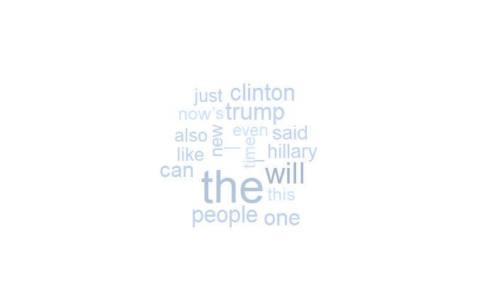

```r
unreliable = rawDF %>% filter(label == 1)
reliable = rawDF %>% filter(label == 0)

wordcloud(unreliable$text, max.words = 20, scale = c(4, 0.8), colors= c("lightsteelblue1","lightsteelblue2","lightsteelblue3","lightsteelblue"))
```

[output not shown]

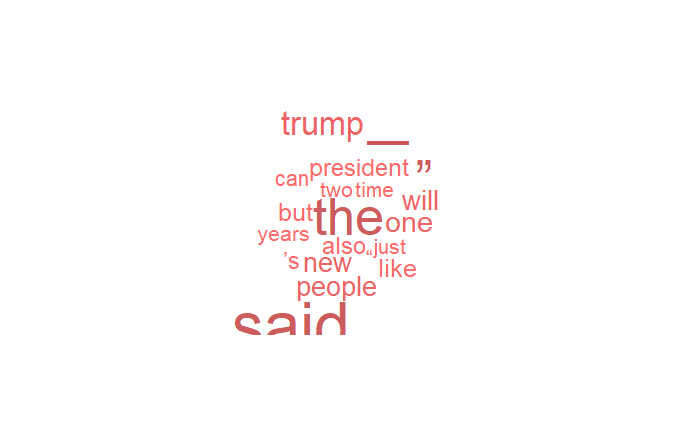

```r
wordcloud(reliable$text, max.words = 20, scale = c(4, 0.8), colors= c("indianred1","indianred2","indianred3","indianred"))
```

The output produces some interesting results. For example, we can see that the word “trump” appears in both wordclouds. Most of the words, however, are generic and do not provide much information (e.g. “the”, “one”, “can”, “just”, etc.).

## Data Preparation

```r
rawDF$label = factor(rawDF$label)
```

As a next step, the Corpus() function is used.

```r
rawCorpus <- Corpus(VectorSource(rawDF$text))
inspect(rawCorpus[1])
```

```
<<SimpleCorpus>>
Metadata:  corpus specific: 1, document level (indexed): 0
Content:  documents: 1

[1] House Dem Aide: We Didn’t Even See Comey’s Letter Until Jason Chaffetz Tweeted It By Darrell Lucus on October 30, 2016 Subscribe Jason Chaffetz on the stump in American Fork, Utah ( image courtesy Michael Jolley, available under a Creative Commons-BY license) \nWith apologies to Keith Olbermann,…
```

The index of each document within the corpus corresponds to the row of the article in our rawDF dataframe.

Next, we will transform all of the text to lowercase and remove the numbers.

```r
cleanedCorpus = rawCorpus %>% tm_map(tolower) %>% tm_map(removeNumbers)
```

```
transformation drops documentstransformation drops documents
```

Next we will use the tm_map() to clean the dataset from interpunction

```r
cleanedCorpus = cleanedCorpus %>% tm_map(removePunctuation) %>% tm_map(removeWords, stopwords(kind = "en"))
```

```
transformation drops documentstransformation drops documents
```

We will also remove some additional characters that tm_map(removePunctuation) has failed to remove in previous attempts.

```r
toSpace = content_transformer(function (x , pattern ) gsub(pattern, " ", x))

cleanedCorpus = tm_map(cleanedCorpus, toSpace, "—")
```

```
transformation drops documents
```

```r
cleanedCorpus = tm_map(cleanedCorpus, toSpace, " ’s")
```

```
transformation drops documents
```

```r
cleanedCorpus = tm_map(cleanedCorpus, toSpace, '“')
```

```
transformation drops documents
```

```r
cleanedCorpus = tm_map(cleanedCorpus, toSpace, '”')
```

```
transformation drops documents
```

```r
inspect(cleanedCorpus[1])
```

```
<<SimpleCorpus>>
Metadata:  corpus specific: 1, document level (indexed): 0
Content:  documents: 1

[1] house dem aide  didn’t even see comey’s letter  jason chaffetz tweeted   darrell lucus  october   subscribe jason chaffetz   stump  american fork utah  image courtesy michael jolley available   creative commonsby license \n apologies  keith olbermann    doubt   worst person   world   week–fbi di…
```

To remove the new inserted whitespace. The tm_map(stripWhitespace) is used.

```r
cleanedCorpus = cleanedCorpus %>% tm_map(stripWhitespace)
```

```
transformation drops documents
```

After this. A comparison is made. this Comparison will show how much there is improved in the set. This done with the tibble() function

```r
tibble(Raw = rawCorpus$content[1], Clean = cleanedCorpus$content[1])
```

| Raw | Clean |
| --- | --- |
| House Dem Aide: We Didn’t Even See Comey’s Letter Until Jason Chaffetz Tweeted It By Darrell Lucus on October 30, 2016 Subscribe Jason Chaffetz on the stump in American Fork, Utah ( image courtesy Mic… | house dem aide didn’t even see comey’s letter jason chaffetz tweeted darrell lucus october subscribe jason chaffetz stump american fork utah image courtesy michael jolley available creative commonsby … |

Now we will transform the corpus to a matrix. The rows in the matrix are the articles and the columns are the individual words. The numbers in the cells show how many times a given word appears in a given article.

```r
cleanDTM = DocumentTermMatrix(cleanedCorpus)
inspect(cleanDTM)
```

```
<<DocumentTermMatrix (documents: 20800, terms: 217652)>>
Non-/sparse entries: 5689600/4521472000
Sparsity           : 100%
Maximal term length: 253
Weighting          : term frequency (tf)
Sample             :
       Terms
Docs    also can like new one people president said trump will
  13534   35  88   65  15  61    149         7   16     0  123
  13746   22  40   54  27  73     36         0   24     0   14
  14294   13  74   34  15  38     58        14    4     0   55
  19032   12  31   56   5  40     73         2   15     1   35
  19765    0   0    0   0   0      0         0    0     0    0
  2735    17  38   29  17  74     53        23   17    65  154
  465     22  14    9   8  22     19         1    5     0   16
  5093    19  45   67  19  60    107         0   10     1   61
  7531    21  60   63  24  62    126         7   11     1  143
  8720    20  67   74  20  46     87         1   22     0  142
```

```r
trainIndex = createDataPartition(rawDF$label, list=FALSE, times = 1, p =.8)
head(trainIndex)
```

```
     Resample1
[1,]         1
[2,]         2
[3,]         3
[4,]         4
[5,]         5
[6,]         6
```

```r
trainingSet = rawDF[trainIndex, ]
```

Next we will create the test set by subtracting the indices of the training set. With splitting them afterward into DTM and Corpus sets

```r
testSet = rawDF[-trainIndex, ]

trainCorpus = cleanedCorpus[trainIndex]
testCorpus = cleanedCorpus[-trainIndex]

trainDTM = cleanDTM[trainIndex, ]
testDTM = cleanDTM[-trainIndex, ]
```

We know from inspecting the DTM above that it has 217652 terms, which means that it has the same number of features.Using all would be inefficient. While a minimum of 500 normally is to high. Anything less produces an object too large to be processed when transforming the DTM later on (due to the limited memory of the author’s laptop. Desktop wise it is fine). Thus, if the code was run on a more powerful machine, a lower minimum frequence is advised (e.g. 5-10)

```r
freqWords = trainDTM %>% findFreqTerms(500)
trainDTM = DocumentTermMatrix(trainCorpus, list(dictionary = freqWords))
testDTM = DocumentTermMatrix(testCorpus, list(dictionary = freqWords))

head(trainDTM)
```

```
<<DocumentTermMatrix (documents: 6, terms: 2473)>>
Non-/sparse entries: 899/13939
Sparsity           : 94%
Maximal term length: 16
Weighting          : term frequency (tf)
```

The number is reduced (i.e. features) to 2473.

Next, the count is converted to be used in the datasets. Which after the test set is shown

```r
CountConversion <- function(x) {
  x = ifelse(x > 0, 1, 0) %>% factor(levels = c(0,1), labels = c("0", "1"))
}

trainDTM <- apply(trainDTM, MARGIN = 2, CountConversion)
testDTM <- apply(testDTM, MARGIN = 2, CountConversion)

head(trainDTM[,1:10])
```

```
    Terms
Docs according acting actually advance agency aide already also american answer
   1 "1"       "1"    "1"      "1"     "1"    "1"  "1"     "1"  "1"      "1"
   2 "0"       "0"    "0"      "0"     "0"    "0"  "0"     "0"  "1"      "0"
   3 "0"       "0"    "0"      "0"     "1"    "0"  "1"     "1"  "1"      "1"
   4 "0"       "0"    "0"      "0"     "0"    "0"  "0"     "0"  "1"      "0"
   5 "1"       "0"    "0"      "0"     "0"    "0"  "0"     "0"  "0"      "0"
   6 "0"       "0"    "0"      "0"     "0"    "0"  "0"     "1"  "0"      "0"
```

## Modeling

To model the dataset. naiveBayes() is used. Which is included in the e1071 library

```r
nbayesModel = naiveBayes(trainDTM, trainingSet$label, laplace = 1)
```

## Evaluation and Deployment

We will store the prediction vector to a new variable and then build run a construction matrix

```r
Prediction = predict(nbayesModel, testDTM)
confusionMatrix(Prediction, testSet$label, positive = "1", dnn = c("Predicted", "Actual"))
```

```
Confusion Matrix and Statistics

         Actual
Predicted    0    1
        0 1326  396
        1  751 1686

               Accuracy : 0.7242
                 95% CI : (0.7104, 0.7378)
    No Information Rate : 0.5006
    P-Value [Acc > NIR] : < 2.2e-16

                  Kappa : 0.4483

 Mcnemar's Test P-Value : < 2.2e-16

            Sensitivity : 0.8098
            Specificity : 0.6384
         Pos Pred Value : 0.6918
         Neg Pred Value : 0.7700
             Prevalence : 0.5006
         Detection Rate : 0.4054
   Detection Prevalence : 0.5860
      Balanced Accuracy : 0.7241

       'Positive' Class : 1
```

# Reviewer adds suggestions for improving the model

1. lines 52 & 53 - the quotes were removed for the values of the label variable as the values are numeric.
2. line 66: Wrong column is referenced. rawDF$type changed to rawDF$label
3. line 86: tm_map(tolower) was removed as it was already run in the previous code chunk
4. lines 89 to 100 were added to remove special characters not captured by tm_map(removePunctuation)
5. line 119: Wrong explanation. The 80% of the instances are used for the training set and 20% for the testing set, not the other way around.
6. line 127: Wrong explaination. There is no “splitting” occuring between the corpus and DTM. I.e. The same observations are used in the training corpus and training DTM. Same for the testing corpus and testing DTM.
7. line 178: Wrong label column and wrong positive class. “testSet$type” was changed to “testSet$label” and “positive =”spam"" was changed to “positive =”1""
8. line 180: Wrong explanation. the proportion of false positives and false negatives is not a result of false negatives being more costly.